# Act3 GWR

Equipo 1

2023-04-25

Load libraries

```r
library(sf)
library(tmap)
library(spdep)
library(rgdal)
library(tidyverse)
library(tigris)
library(mapview)
library(GWmodel)
library(regclass)
library(viridis)
library(grid)
library(RColorBrewer)
library(rgeoda)
library(sjPlot)
library(jtools)
library(dlookr)
library(terra)
library(ggpubr)
library(rstatix)
```

Set directory

```r
getwd()
```

```
## [1] "C:/Users/ntybl/OneDrive/Documents/Semestre 8"
```

```r
setwd("C:/Users/ntybl/OneDrive/Documents/Semestre 8/Datos")
getwd()
```

```
## [1] "C:/Users/ntybl/OneDrive/Documents/Semestre 8/Datos"
```

Importing non-spatial data and geospatial data (shapefile) Unir las bases de datos para poder crear los mapas

```r
covid_shpf <-  readOGR(dsn = "C:\\Users\\ntybl\\Downloads\\spda_covid19 (3)\\spda_covid19\\shp_mx_mpios\\mx_mpios.shp")
covid_df <- read.csv("C:\\Users\\ntybl\\OneDrive\\Documents\\Semestre 8\\Datos\\datosFinal.csv")
covid_j <- geo_join(covid_shpf,covid_df,'IDUNICO','IDUNICO',how='inner') ### Combining geospatial and non-spatial data
```

# Limpieza de datos

```r
summary(covid_shpf)
```

```
## Object of class SpatialPolygonsDataFrame
## Coordinates:
##         min       max
## x -118.4076 -86.71041
## y   14.5321  32.71865
## Is projected: FALSE
## proj4string : [+proj=longlat +datum=WGS84 +no_defs]
## Data attributes:
##    CODELAG             CVE_ENT         IDUNICO
##  Length:2456        Min.   : 1.00   Min.   : 1001
##  Class :character   1st Qu.:14.00   1st Qu.:14084
##  Mode  :character   Median :20.00   Median :20231
##                     Mean   :19.26   Mean   :19367
##                     3rd Qu.:24.00   3rd Qu.:24030
##                     Max.   :32.00   Max.   :32058
```

```r
summary(covid_df)
```

```
##     IDUNICO            n               mpio           poblacion_2022
##  Min.   : 1001   Min.   :   1.00   Length:2460        Min.   :     95
##  1st Qu.:14083   1st Qu.:   3.00   Class :character   1st Qu.:   4470
##  Median :20231   Median :  11.00   Mode  :character   Median :  14137
##  Mean   :19360   Mean   :  87.96                      Mean   :  52012
##  3rd Qu.:24029   3rd Qu.:  41.00                      3rd Qu.:  37099
##  Max.   :32058   Max.   :4993.00                      Max.   :1815551
##                  NA's   :68                           NA's   :3
##   hogrem2015        hogremjefmuj2015   popnoafmed2015       gini2015
##  Length:2460        Length:2460        Length:2460        Length:2460
##  Class :character   Class :character   Class :character   Class :character
##  Mode  :character   Mode  :character   Mode  :character   Mode  :character
##
##
##
##
##   popden2020         crimen_2018      crimen_2019     inclusion_fin_2019
##  Length:2460        Min.   :  0.00   Min.   :  0.00   Min.   : 0.0000
##  Class :character   1st Qu.:  0.00   1st Qu.:  0.00   1st Qu.: 0.0000
##  Mode  :character   Median :  9.75   Median : 11.50   Median : 0.0000
##                     Mean   : 19.02   Mean   : 20.30   Mean   : 0.4876
##                     3rd Qu.: 25.71   3rd Qu.: 26.95   3rd Qu.: 0.8500
##                     Max.   :719.42   Max.   :551.82   Max.   :10.6800
##                     NA's   :3        NA's   :3        NA's   :3
##  porcentaje_pob_pobreza porcentaje_pob_pobreza_ext
##  Length:2460            Length:2460
##  Class :character       Class :character
##  Mode  :character       Mode  :character
##
##
##
##
##  porcentaje_pob_servicios_salud porcentaje_pob_acceso_ss pob_6.14_no_edu
##  Length:2460                    Length:2460              Min.   : 0.000
##  Class :character               Class :character         1st Qu.: 4.170
##  Mode  :character               Mode  :character         Median : 5.720
##                                                          Mean   : 6.304
##                                                          3rd Qu.: 7.810
##                                                          Max.   :38.560
##                                                          NA's   :3
```

[output cut: 49 more lines]

```
##  Min.   :   0.00   Min.   :   0.00   Length:2460        Min.   :     0.00
##  1st Qu.:   0.00   1st Qu.:   0.00   Class :character   1st Qu.:    14.75
##  Median :   1.00   Median :   1.00   Mode  :character   Median :    63.00
##  Mean   :  33.14   Mean   :  48.76                      Mean   :  1085.73
##  3rd Qu.:   6.00   3rd Qu.:   6.00                      3rd Qu.:   301.25
##  Max.   :4854.00   Max.   :4708.00                      Max.   :115547.00
##  NA's   :3         NA's   :3
##   tasa_covid         total_casos
##  Length:2460        Min.   :     0.0
##  Class :character   1st Qu.:    22.0
##  Mode  :character   Median :   102.5
##                     Mean   :  1704.7
##                     3rd Qu.:   454.5
##                     Max.   :168500.0
##
```

Convertir a numeric

```r
covid_df$porcentaje_pob_acceso_ss <- as.numeric(covid_df$porcentaje_pob_acceso_ss)
covid_df$porcentaje_pob_pobreza <- as.numeric(covid_df$porcentaje_pob_pobreza)
covid_df$porcentaje_pob_servicios_salud <- as.numeric(covid_df$porcentaje_pob_servicios_salud)
covid_df$hogremjefmuj2015 <- as.numeric(covid_df$hogremjefmuj2015)
covid_df$tasa_covid <- as.numeric(covid_df$tasa_covid)
covid_df$hogrem2015 <- as.numeric(covid_df$hogrem2015)
covid_df$popnoafmed2015 <- as.numeric(covid_df$popnoafmed2015)
covid_df$gini2015 <- as.numeric(covid_df$gini2015)
covid_df$popden2020 <- as.numeric(covid_df$popden2020)
covid_df$porcentaje_pob_pobreza_ext <- as.numeric(covid_df$porcentaje_pob_pobreza_ext)
```

Convertir a factor

```r
covid_df$REGION <- as.factor(covid_df$REGION)
```

Convertir NA a la mediana

```r
covid_df <- covid_df %>% mutate(across(where(is.numeric), ~ replace_na(., median(., na.rm = TRUE))))
```

Cambiar 0 a 0.01

```r
covid_df$tasa_covid <- replace(covid_df$tasa_covid, covid_df$tasa_covid == 0, 0.01)
covid_df$crimen_2019 <- replace(covid_df$crimen_2019, covid_df$crimen_2019 == 0, 0.01)
```

```r
summary(covid_j)
```

```
## Object of class SpatialPolygonsDataFrame
## Coordinates:
##         min       max
## x -118.4076 -86.71041
## y   14.5321  32.71865
## Is projected: FALSE
## proj4string : [+proj=longlat +datum=WGS84 +no_defs]
## Data attributes:
##    CODELAG             CVE_ENT         IDUNICO        IDUNICO.1
##  Length:2456        Min.   : 1.00   Min.   : 1001   Min.   : 1001
##  Class :character   1st Qu.:14.00   1st Qu.:14084   1st Qu.:14084
##  Mode  :character   Median :20.00   Median :20231   Median :20231
##                     Mean   :19.26   Mean   :19367   Mean   :19367
##                     3rd Qu.:24.00   3rd Qu.:24030   3rd Qu.:24030
##                     Max.   :32.00   Max.   :32058   Max.   :32058
##
##        n               mpio           poblacion_2022     hogrem2015
##  Min.   :   1.00   Length:2456        Min.   :     95   Length:2456
##  1st Qu.:   3.00   Class :character   1st Qu.:   4468   Class :character
##  Median :  11.00   Mode  :character   Median :  14129   Mode  :character
##  Mean   :  88.07                      Mean   :  52014
##  3rd Qu.:  41.00                      3rd Qu.:  37095
##  Max.   :4993.00                      Max.   :1815551
##  NA's   :68
##  hogremjefmuj2015   popnoafmed2015       gini2015          popden2020
##  Length:2456        Length:2456        Length:2456        Length:2456
##  Class :character   Class :character   Class :character   Class :character
##  Mode  :character   Mode  :character   Mode  :character   Mode  :character
##
##
##
##
##   crimen_2018       crimen_2019     inclusion_fin_2019 porcentaje_pob_pobreza
##  Min.   :  0.000   Min.   :  0.00   Min.   : 0.0000    Length:2456
##  1st Qu.:  0.000   1st Qu.:  0.00   1st Qu.: 0.0000    Class :character
##  Median :  9.745   Median : 11.49   Median : 0.0000    Mode  :character
##  Mean   : 19.006   Mean   : 20.29   Mean   : 0.4869
##  3rd Qu.: 25.695   3rd Qu.: 26.91   3rd Qu.: 0.8425
##  Max.   :719.420   Max.   :551.82   Max.   :10.6800
##
```

[output cut: 65 more lines]

```
##  Min.   :   0.00   Length:2456        Min.   :     0.0   Length:2456
##  1st Qu.:   0.00   Class :character   1st Qu.:    15.0   Class :character
##  Median :   1.00   Mode  :character   Median :    63.5   Mode  :character
##  Mean   :  48.77                      Mean   :  1087.4
##  3rd Qu.:   6.00                      3rd Qu.:   301.2
##  Max.   :4708.00                      Max.   :115547.0
##
##   total_casos
##  Min.   :     0.0
##  1st Qu.:    22.0
##  Median :   103.0
##  Mean   :  1707.3
##  3rd Qu.:   454.5
##  Max.   :168500.0
##
```

Convertir a numeric

```r
covid_j$hogrem2015 <- as.numeric(covid_j$hogrem2015)
covid_j$hogremjefmuj2015 <- as.numeric(covid_j$hogremjefmuj2015)
covid_j$popnoafmed2015 <- as.numeric(covid_j$popnoafmed2015)
covid_j$gini2015 <- as.numeric(covid_j$gini2015)
covid_j$popden2020 <- as.numeric(covid_j$popden2020)
covid_j$porcentaje_pob_pobreza <- as.numeric(covid_j$porcentaje_pob_pobreza)
covid_j$porcentaje_pob_pobreza_ext <- as.numeric(covid_j$porcentaje_pob_pobreza_ext)
covid_j$porcentaje_pob_servicios_salud <-  as.numeric(covid_j$porcentaje_pob_servicios_salud)
covid_j$porcentaje_pob_acceso_ss <- as.numeric(covid_j$porcentaje_pob_acceso_ss)
covid_j$tasa_covid <- as.numeric(covid_j$tasa_covid)
```

Cambiar 0 por 0.01

```r
covid_j$crimen_2019[covid_j$crimen_2019 == 0 ] <- 0.01
covid_j$tasa_covid[covid_j$tasa_covid == 0 ] <- 0.01
covid_j$hogremjefmuj2015[covid_j$hogremjefmuj2015 == 0] <- 0.01
covid_j$REGION <- as.factor(covid_j$REGION)
```

Cambiar NAs por la mediana

```r
covid_j$n[is.na(covid_j$n)] <- 11.00
covid_j$porcentaje_pob_servicios_salud[is.na(covid_j$porcentaje_pob_servicios_salud)] <- 23.22
covid_j$porcentaje_pob_acceso_ss[is.na(covid_j$porcentaje_pob_acceso_ss)] <- 76.46
covid_j$porcentaje_pob_pobreza[is.na(covid_j$porcentaje_pob_pobreza)] <- 62.60
covid_j$porcentaje_pob_pobreza_ext[is.na(covid_j$porcentaje_pob_pobreza_ext)] <- 12.48
```

# Objetivos

- Predecir los factores asociados con el incremento / disminución de casos confirmados de COVID-19
- Visualizar y analizar clusters en nuestras variables de interés
- Estimación regresión espacial global y local
- Comparar los resultados de las diferentes regresiones que se realizaran

# Visualización de las variables

visualización de casos confirmados de covid 19 y factores socioeconómicos

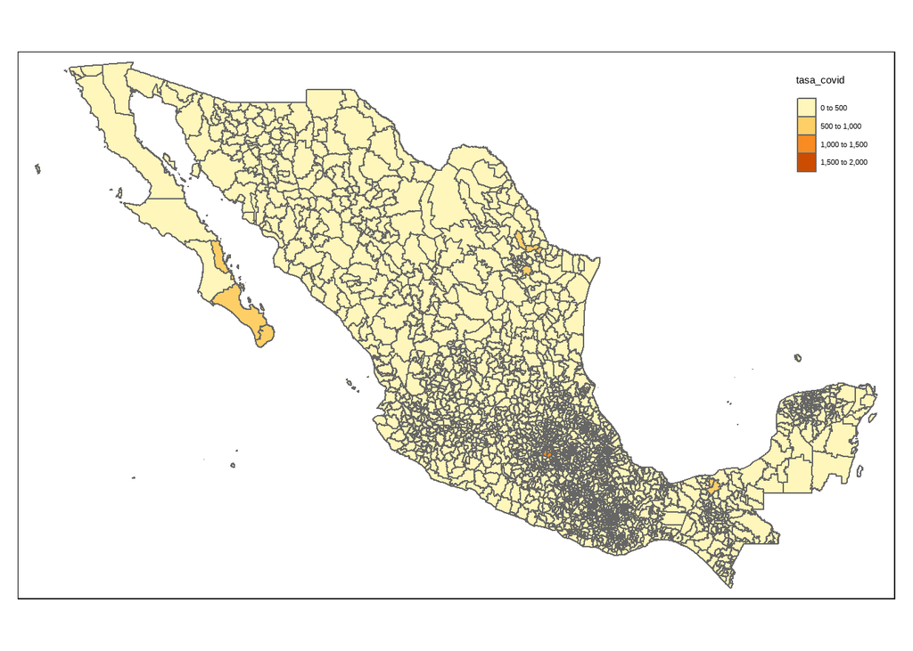

```r
qtm(covid_j, "tasa_covid")
```

En el mapa anterior podemos visualizar los casos de COVID confirmados en una taza de cada 10 por el total de casos, podemos notar concentraciones en 3 áreas especificas estas siendo Baja California sur, Tabasco, Nuevo León y una alta concentración en el Estado de México.

```r
qtm(covid_j, "rezago_social")
```

```
## Variable(s) "rezago_social" contains positive and negative values, so midpoint is set to 0. Set midpoint = NA to show the full spectrum of the color palette.
```

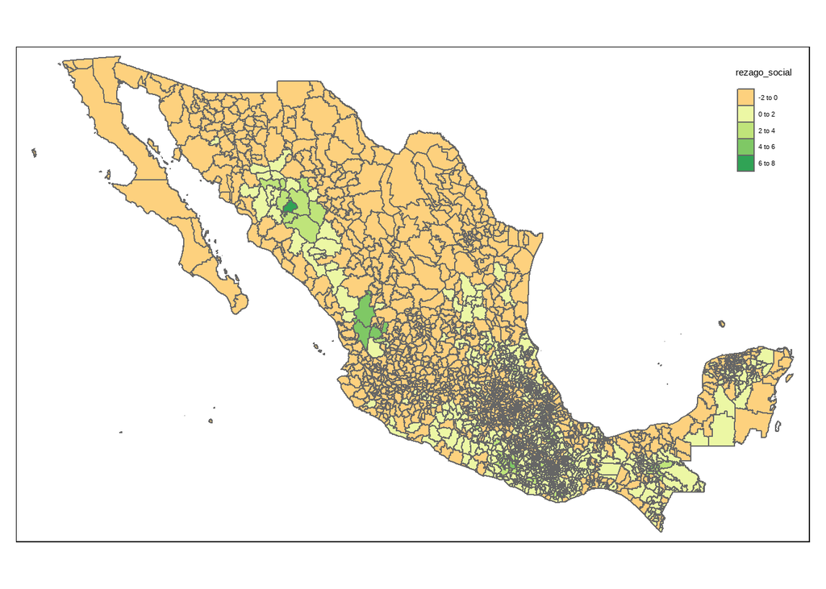

```r
#mapview(covid_j, zcol="rezago_social")
```

En el mapa anterior se pueden visualizar clusters podemos visualizar un alto grado de rezago social en la región norte del país a lo largo de los estados de Sonora, Chihuahua, Sinaloa, Durango y Nayarit.

En cuanto al centro y sur del país podemos visualizar concentraciones de rezago social a lo largo de estas regiones.

H0: La distribución del rezago social por estado se distribuye aleatoriamente. H1: La distribución del rezago social por estado no se distribuye aleatoriamente, hay conglomerados (autocorrelación positiva) o valores atípicos (autocorrelación negativa)

Modelado de vecinos espaciales y matrices de conectividad espacial

```r
swm_queen2 <- poly2nb(covid_shpf, queen = TRUE)
summary(swm_queen2)
```

```
## Neighbour list object:
## Number of regions: 2456
## Number of nonzero links: 14392
## Percentage nonzero weights: 0.2385967
## Average number of links: 5.859935
## Link number distribution:
##
##   1   2   3   4   5   6   7   8   9  10  11  12  13  14  15  16  17  19  20  22
##   8  63 202 393 515 467 317 233 143  52  27  15   5   4   3   3   1   1   1   3
## 8 least connected regions:
## 299 354 667 858 930 1243 1461 2234 with 1 link
## 3 most connected regions:
## 966 1058 1173 with 22 links
```

Resumen de la matriz de peso espacial Hay 2,456 municipios en México La unidad de área más conectada tiene 22 vecinos La unidad del área menos conectada tiene 1 vecino

```r
swm_rook2 <- poly2nb(covid_shpf, queen = FALSE)
summary(swm_rook2)
```

```
## Neighbour list object:
## Number of regions: 2456
## Number of nonzero links: 14176
## Percentage nonzero weights: 0.2350158
## Average number of links: 5.771987
## Link number distribution:
##
##   1   2   3   4   5   6   7   8   9  10  11  12  13  14  15  16  17  19  20  21
##   8  68 217 416 507 461 321 230 119  52  23  13   6   4   4   1   1   1   2   1
##  22
##   1
## 8 least connected regions:
## 299 354 667 858 930 1243 1461 2234 with 1 link
## 1 most connected region:
## 1058 with 22 links
```

Trazado de mapas de vecinos basados en la contigüidad de queen

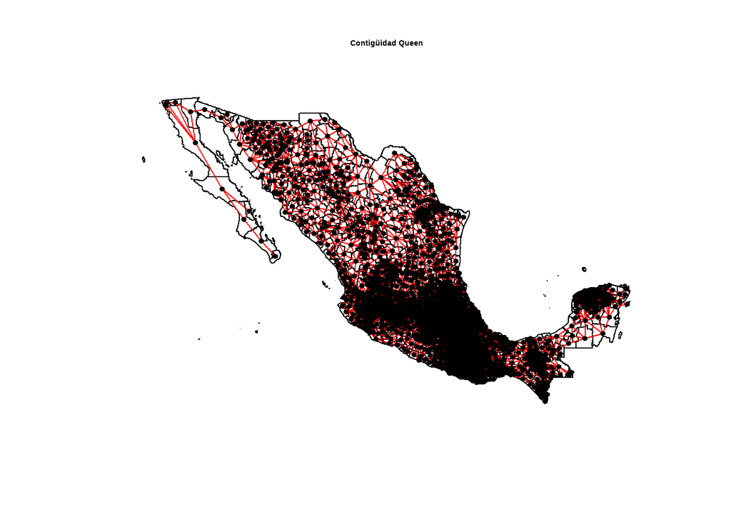

```r
plot(covid_shpf, borders = 'lightgrey')
plot(swm_queen2, coordinates(covid_shpf), pch = 19, cex = 0.6, add = TRUE, col = "red")
title(main = "Contigüidad Queen", cex.main = 0.9)
```

Trazado de mapas de vecinos basados en la contigüidad de rook

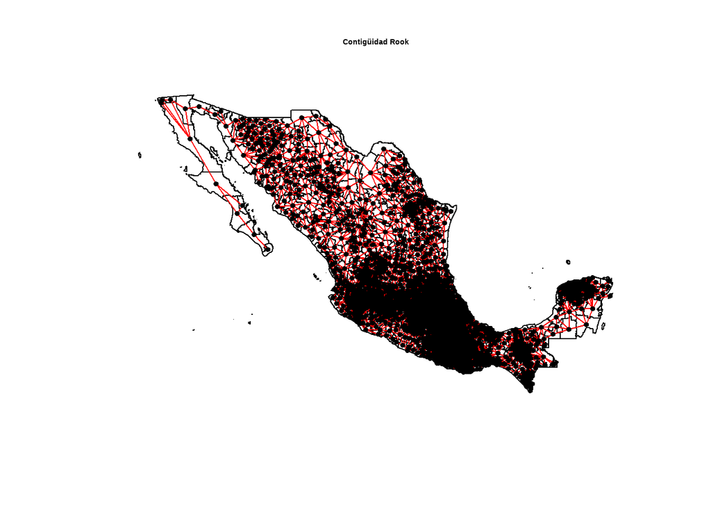

```r
plot(covid_shpf, borders = 'lightgrey')
plot(swm_rook2, coordinates(covid_shpf), pch = 19, cex = 0.6, add = TRUE, col = "red")
title(main = "Contigüidad Rook", cex.main = 0.9)
```

Cálculo de vecinos basados en distancia

```r
coords2 <- coordinates(covid_shpf)
head(coords2)
```

```
##        [,1]     [,2]
## 0 -99.20622 19.19834
## 1 -99.09036 19.24515
## 2 -99.26841 19.26898
## 3 -99.18211 19.48533
## 4 -99.16113 19.38064
## 5 -99.14906 19.43137
```

```r
knn2 <- knn2nb(knearneigh(coords2))
knn1_dist2 <- unlist(nbdists(knn2, coords2, longlat = TRUE))
summary(knn1_dist2)
```

```
##    Min. 1st Qu.  Median    Mean 3rd Qu.    Max.
##   0.558   7.387  11.413  15.811  19.110 229.364
```

En promedio, ¿cada municipio es el más cercano en distancia a otras 122 áreas de puntos?

```r
dwm2 <- dnearneigh(coords2, 0 ,98, longlat = TRUE)
dwm2
```

```
## Neighbour list object:
## Number of regions: 2456
## Number of nonzero links: 298802
## Percentage nonzero weights: 4.953667
## Average number of links: 121.6621
## 5 regions with no links:
## 348 352 353 355 2448
```

```r
rswm_queen2 <- nb2listw(swm_queen2, style = "W", zero.policy = TRUE)
rswm_queen2
```

```
## Characteristics of weights list object:
## Neighbour list object:
## Number of regions: 2456
## Number of nonzero links: 14392
## Percentage nonzero weights: 0.2385967
## Average number of links: 5.859935
##
## Weights style: W
## Weights constants summary:
##      n      nn   S0       S1       S2
## W 2456 6031936 2456 898.7549 10338.48
```

Vamos a crear un spatial lag de la variable del conjunto de datos.

```r
covid_j$sp_rezago_social<- lag.listw(rswm_queen2, covid_j$rezago_social, zero.policy = TRUE)
```

```r
qtm(covid_j, "rezago_social" )
```

```
## Variable(s) "rezago_social" contains positive and negative values, so midpoint is set to 0. Set midpoint = NA to show the full spectrum of the color palette.
```

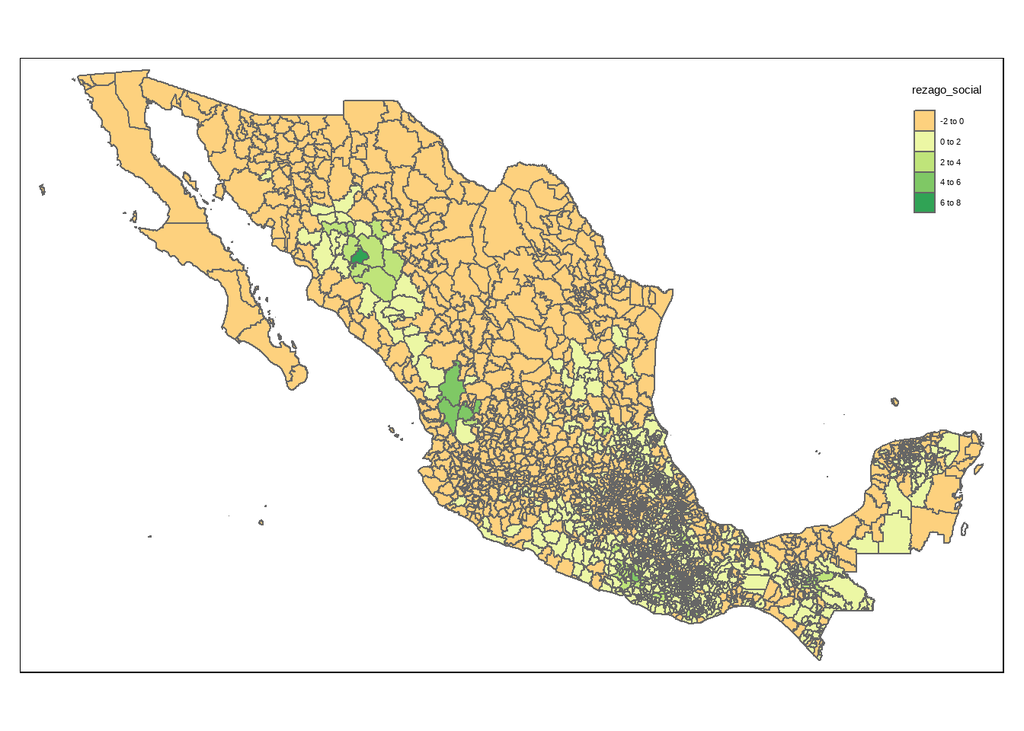

```r
qtm(covid_j, "sp_rezago_social")
```

```
## Variable(s) "sp_rezago_social" contains positive and negative values, so midpoint is set to 0. Set midpoint = NA to show the full spectrum of the color palette.
```

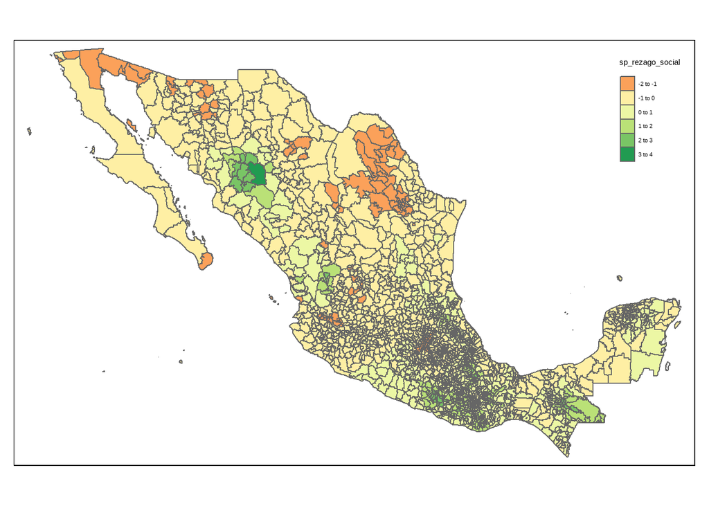

En los mapas anteriores se comparar el rezago social en México y el spatial lag de rezago social, podemos notar una mayor concentración en el mapa de lag tanto en negativo como en positivo a comparación del mapa sin lag, la principal observación seria que el mapa de spatial lag muestra una alta concentración entre los valores de -1 a 0. también podemos notar más valores positivos entre 1 y 2 a comparación del mapa de rezago.

Moran’s I Test

Identificar y medir la autocorrelación espacial

```r
moran.test(covid_j$rezago_social, listw = rswm_queen2, zero.policy = TRUE, na.action = na.omit)
```

```
##
##  Moran I test under randomisation
##
## data:  covid_j$rezago_social
## weights: rswm_queen2
##
## Moran I statistic standard deviate = 56.494, p-value < 2.2e-16
## alternative hypothesis: greater
## sample estimates:
## Moran I statistic       Expectation          Variance
##      0.6879873175     -0.0004073320      0.0001484831
```

En conclusión, los resultados sugieren que existe una autocorrelación espacial positiva significativa en la variable analizada, lo que indica que las ubicaciones vecinas tienden a tener valores similares.

Computar el correlograma I de moran

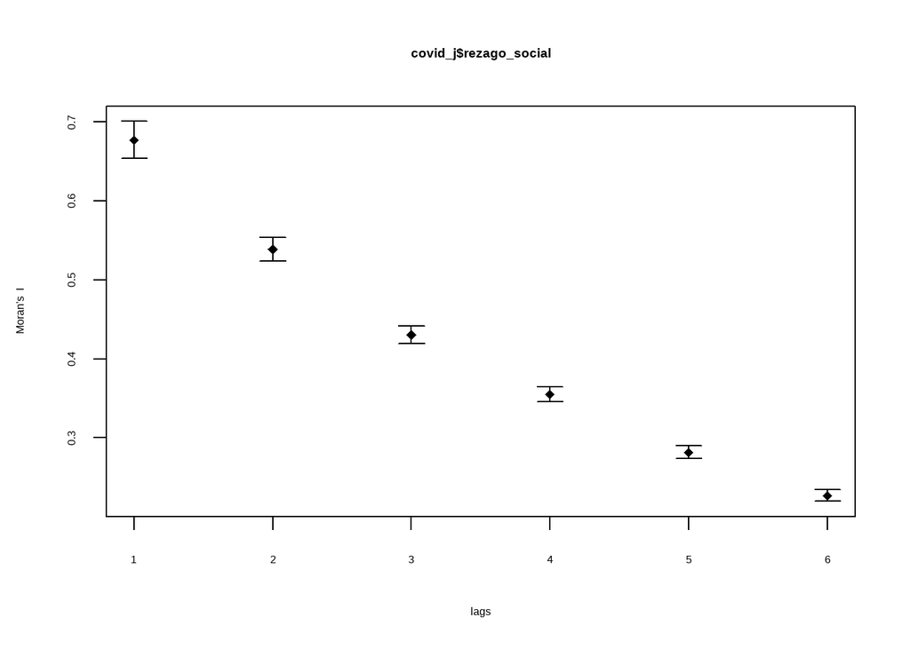

```r
Moran_cor <- sp.correlogram(swm_queen2, covid_j$rezago_social, order = 6, method = "I", style = "B")
plot(Moran_cor)
```

En general, el correlograma indica que existe una autocorrelación espacial positiva en la variable que se analiza, con observaciones vecinas que tienen valores similares. La fuerza de la autocorrelación espacial se debilita gradualmente a medida que aumenta la distancia entre las observaciones, y el efecto de las observaciones vecinas disminuye más allá de cierta distancia.

Exploremos el análisis de datos espaciales y modelemos las relaciones espaciales locales

A continuación, haremos un normality plot para analizar la distribución de las variables y concluir si estas necesitan ser alteradas

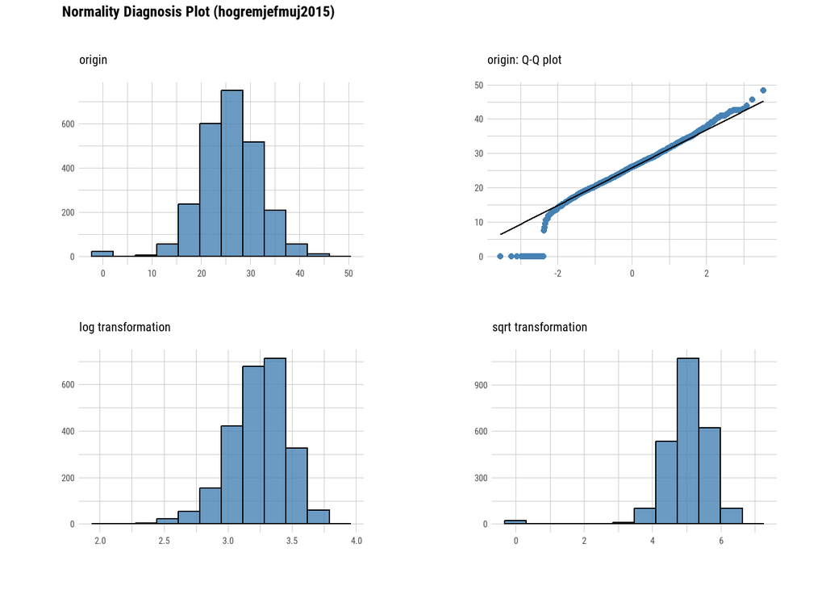

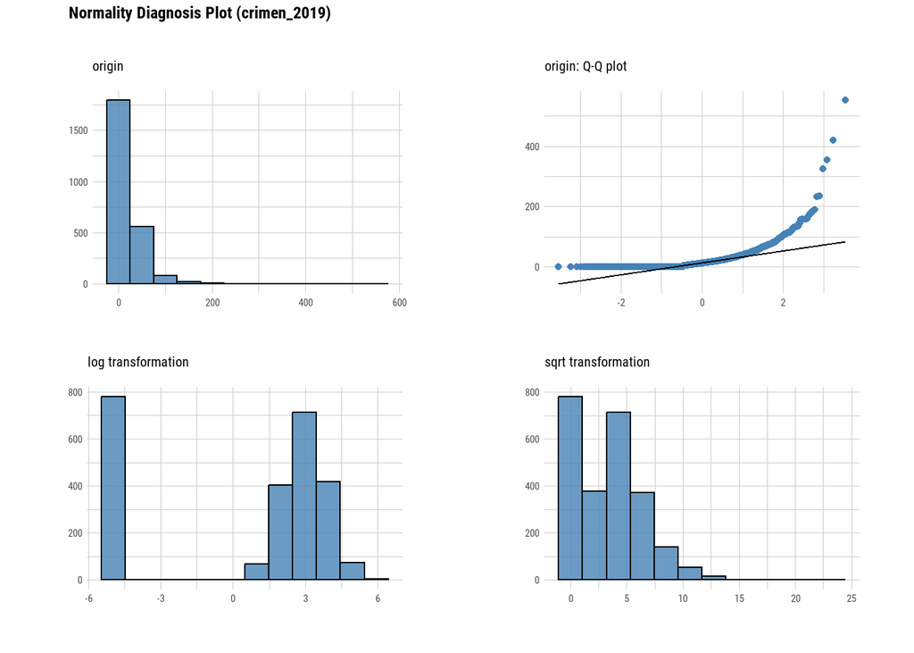

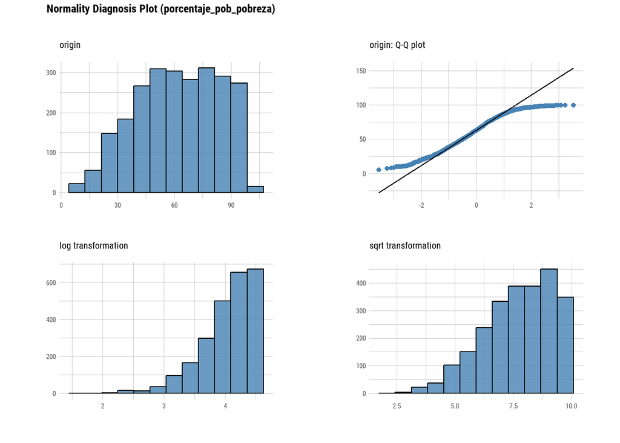

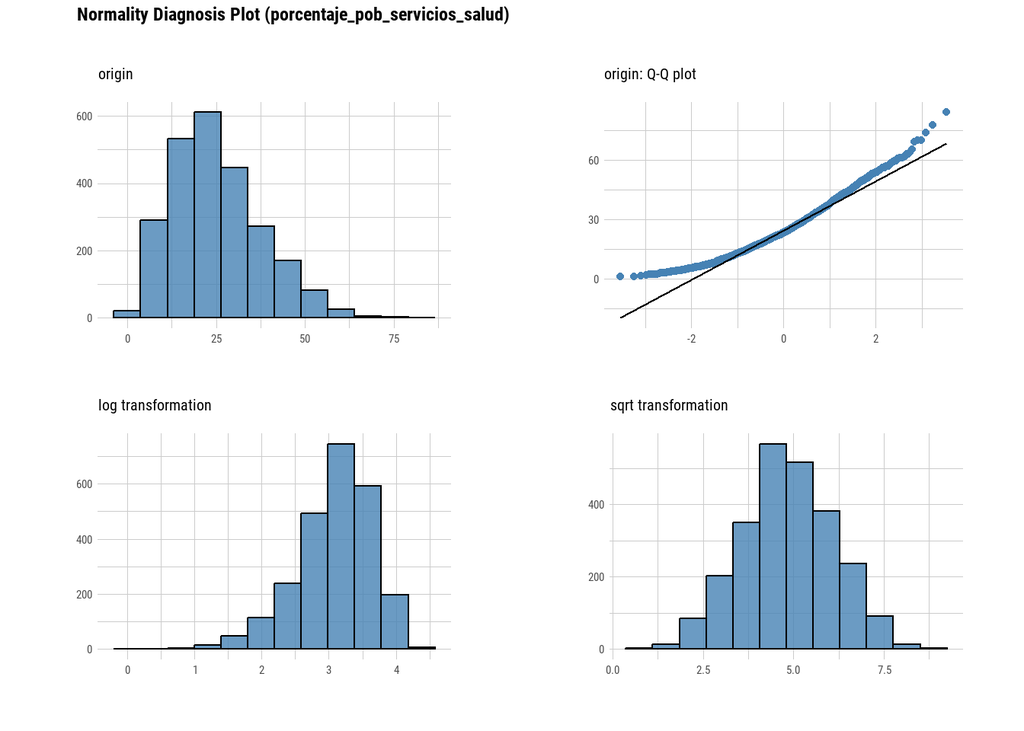

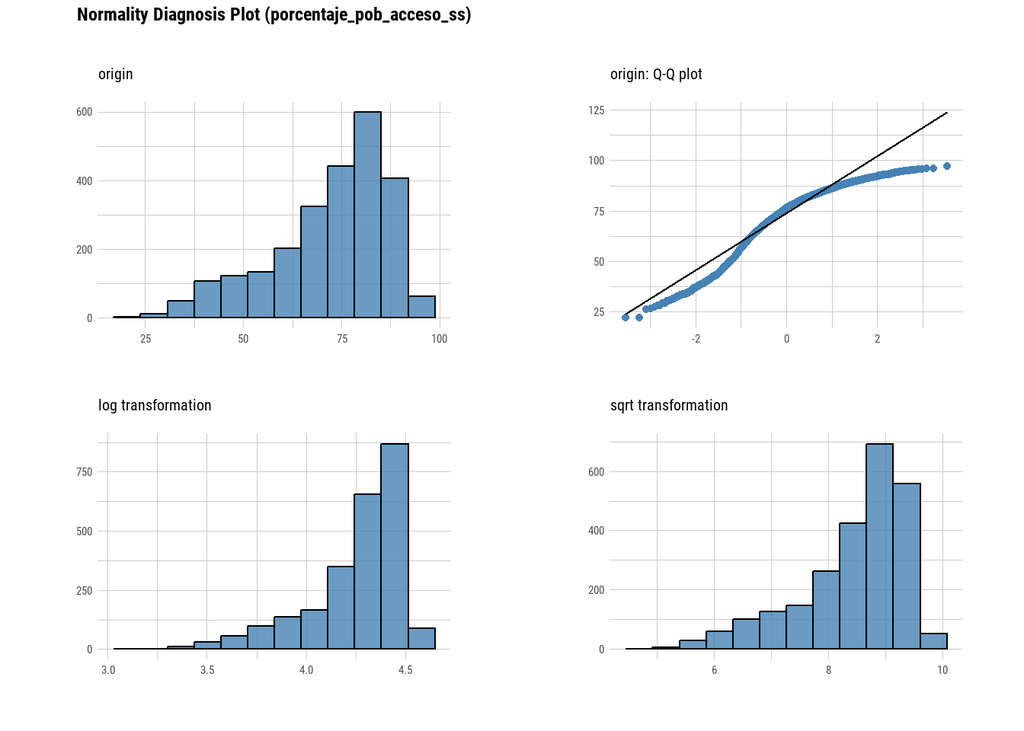

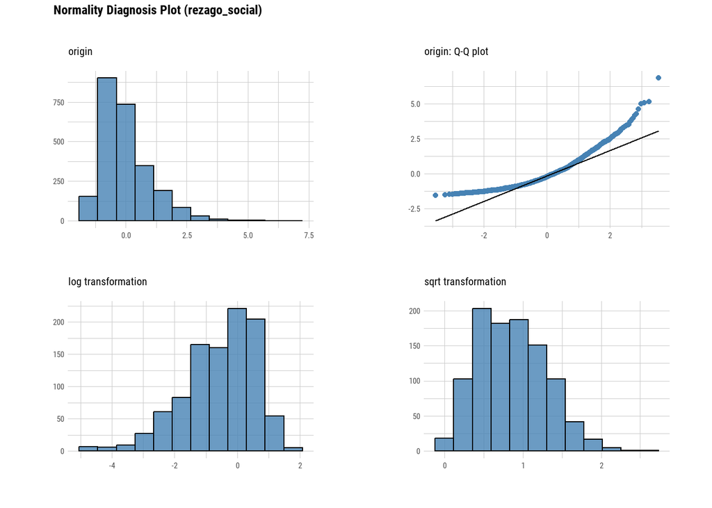

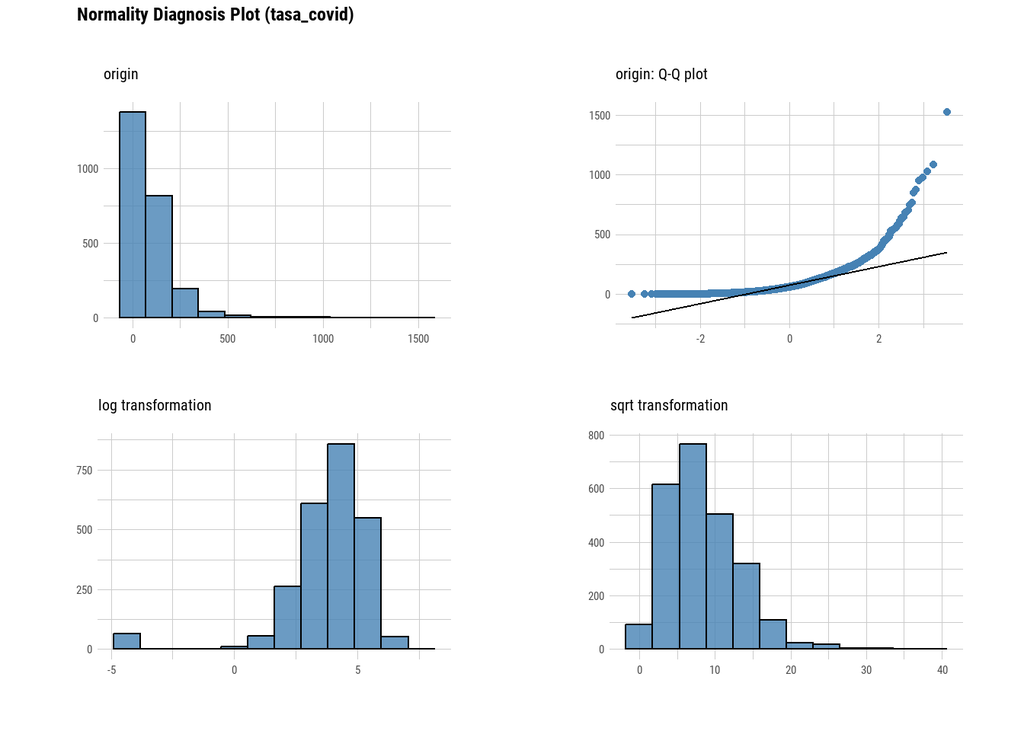

```r
plot_normality(covid_df, hogremjefmuj2015, crimen_2019, porcentaje_pob_pobreza, porcentaje_pob_servicios_salud, porcentaje_pob_acceso_ss, rezago_social, porcentaje_pob_pobreza, tasa_covid)
```

En base a los resultados usaremos log en las variables: tasa_covid (variable dependiente) y crimen_2019.

# Regresion no espacial

```r
non_spatial_model2 = lm(log(tasa_covid) ~ hogremjefmuj2015 + log(crimen_2019) + porcentaje_pob_servicios_salud + porcentaje_pob_acceso_ss + rezago_social + porcentaje_pob_pobreza + REGION, data = covid_df)

summary(non_spatial_model2)
```

```
##
## Call:
## lm(formula = log(tasa_covid) ~ hogremjefmuj2015 + log(crimen_2019) +
##     porcentaje_pob_servicios_salud + porcentaje_pob_acceso_ss +
##     rezago_social + porcentaje_pob_pobreza + REGION, data = covid_df)
##
## Residuals:
##     Min      1Q  Median      3Q     Max
## -8.7896 -0.4613  0.1233  0.7076  3.5079
##
## Coefficients:
##                                  Estimate Std. Error t value Pr(>|t|)
## (Intercept)                     5.7172576  0.2855323  20.023  < 2e-16 ***
## hogremjefmuj2015                0.0145767  0.0050986   2.859  0.00429 **
## log(crimen_2019)                0.0650888  0.0086855   7.494 9.28e-14 ***
## porcentaje_pob_servicios_salud  0.0001964  0.0026083   0.075  0.93997
## porcentaje_pob_acceso_ss       -0.0025806  0.0029666  -0.870  0.38445
## rezago_social                  -0.3086272  0.0513128  -6.015 2.07e-09 ***
## porcentaje_pob_pobreza         -0.0304026  0.0030041 -10.120  < 2e-16 ***
## REGIONCENTRO NORTE             -0.5194208  0.0962660  -5.396 7.48e-08 ***
## REGIONNORTE                    -0.3463307  0.1285403  -2.694  0.00710 **
## REGIONSUR                      -0.3204493  0.0818138  -3.917 9.22e-05 ***
## ---
## Signif. codes:  0 '***' 0.001 '**' 0.01 '*' 0.05 '.' 0.1 ' ' 1
##
## Residual standard error: 1.441 on 2450 degrees of freedom
## Multiple R-squared:  0.3482, Adjusted R-squared:  0.3458
## F-statistic: 145.4 on 9 and 2450 DF,  p-value: < 2.2e-16
```

```r
VIF(non_spatial_model2)
```

```
##                                    GVIF Df GVIF^(1/(2*Df))
## hogremjefmuj2015               1.140313  1        1.067855
## log(crimen_2019)               1.165702  1        1.079677
## porcentaje_pob_servicios_salud 1.248341  1        1.117292
## porcentaje_pob_acceso_ss       2.283268  1        1.511049
## rezago_social                  3.121308  1        1.766722
## porcentaje_pob_pobreza         5.116764  1        2.262026
## REGION                         2.496127  3        1.164692
```

Interpretacion:

- El intercepto tiene un valor estimado de 5,717, que representa el valor esperado de la variable dependiente cuando todas las variables independientes son iguales a cero.
- El valor R-cuadrado de 0.3482 sugiere que aproximadamente el 34.82 % de la varianza de la variable dependiente puede explicarse por las variables independientes.
- El F-statistic de 145.4 con un p-value de < 2.2e-16 sugiere que el modelo en su conjunto es estadísticamente significativo.
- Los residuos tienen un valor mínimo de -8.7896 y un valor máximo de 3.5079, con una media de aproximadamente cero, lo que indica que la suposición de errores normalmente distribuidos es razonable.

-La varible porcentaje_pob_pobreza muestra un VIF de 5.116764 esta muestra multicollinearity por lo cual será removida del modelo.

```r
AIC(non_spatial_model2)
```

```
## [1] 8790.453
```

# Global Spatial Regression Analysis

Convertir a sp

```r
covid.sp = as(covid_shpf, "Spatial")
```

```r
spatial_auto <- lagsarlm(log(tasa_covid) ~ hogremjefmuj2015 + log(crimen_2019) + porcentaje_pob_servicios_salud + porcentaje_pob_acceso_ss + rezago_social + porcentaje_pob_pobreza + REGION, data = covid_j, listw = rswm_queen2, Durbin = FALSE)
summary(spatial_auto)
```

```
##
## Call:
## lagsarlm(formula = log(tasa_covid) ~ hogremjefmuj2015 + log(crimen_2019) +
##     porcentaje_pob_servicios_salud + porcentaje_pob_acceso_ss +
##     rezago_social + porcentaje_pob_pobreza + REGION, data = covid_j,
##     listw = rswm_queen2, Durbin = FALSE)
##
## Residuals:
##      Min       1Q   Median       3Q      Max
## -8.69596 -0.39978  0.11408  0.61356  3.93984
##
## Type: lag
## Coefficients: (asymptotic standard errors)
##                                   Estimate  Std. Error z value  Pr(>|z|)
## (Intercept)                     3.71278485  0.30459866 12.1891 < 2.2e-16
## hogremjefmuj2015                0.01482141  0.00484015  3.0622  0.002197
## log(crimen_2019)                0.05549374  0.00827233  6.7084 1.968e-11
## porcentaje_pob_servicios_salud  0.00018247  0.00248020  0.0736  0.941352
## porcentaje_pob_acceso_ss       -0.00212963  0.00281814 -0.7557  0.449837
## rezago_social                  -0.24798032  0.04909005 -5.0515 4.383e-07
## porcentaje_pob_pobreza         -0.02253814  0.00291559 -7.7302 1.066e-14
## REGIONCENTRO NORTE             -0.41501515  0.09193795 -4.5141 6.359e-06
## REGIONNORTE                    -0.30893457  0.12204657 -2.5313  0.011365
## REGIONSUR                      -0.15084423  0.07913821 -1.9061  0.056639
##
## Rho: 0.35781, LR test value: 191.11, p-value: < 2.22e-16
## Asymptotic standard error: 0.0254
##     z-value: 14.087, p-value: < 2.22e-16
## Wald statistic: 198.45, p-value: < 2.22e-16
##
## Log likelihood: -4283.414 for lag model
## ML residual variance (sigma squared): 1.8708, (sigma: 1.3678)
## Number of observations: 2456
## Number of parameters estimated: 12
## AIC: 8590.8, (AIC for lm: 8779.9)
## LM test for residual autocorrelation
## test value: 1.475, p-value: 0.22455
```

- El AIC del modelo Global Spatial Regression es 8590.8, que es inferior al AIC del modelo de Regresion no espacial (8790.453).

Detección de residuos de regresión espacialmente autocorrelacionados

```r
moran.test(exp(spatial_auto$residuals), rswm_queen2)
```

```
##
##  Moran I test under randomisation
##
## data:  exp(spatial_auto$residuals)
## weights: rswm_queen2
##
## Moran I statistic standard deviate = 10.285, p-value < 2.2e-16
## alternative hypothesis: greater
## sample estimates:
## Moran I statistic       Expectation          Variance
##       0.121717673      -0.000407332       0.000141004
```

El p-value de 2.2e-16 indica que la hipótesis nula (es decir, la ausencia de autocorrelación espacial) se puede rechazar con un grado de confianza muy alto. La hipótesis alternativa es mayor, lo que significa que los datos exhiben una autocorrelación espacial positiva.

# Local Spatial Regression Analysis

Determinar kernel bandwidth

El modelo de Kennel Barwidth nos demuestra a qué distancia dos objetos deben estar para darle significancia o tener influencia en los resultados. Una distancia cercana indica que las estimaciones están cerca de los datos mientras que una distancia lejana proporciona una transición más fácil de realizar.

```r
bw4 <- bw.gwr(log(tasa_covid) ~ hogremjefmuj2015 + log(crimen_2019) + porcentaje_pob_servicios_salud + porcentaje_pob_acceso_ss + rezago_social,
              approach = "AIC", adaptive = T, data=covid_j)
```

```
## Take a cup of tea and have a break, it will take a few minutes.
##           -----A kind suggestion from GWmodel development group
## Adaptive bandwidth (number of nearest neighbours): 1525 AICc value: 8673.046
## Adaptive bandwidth (number of nearest neighbours): 950 AICc value: 8590.03
## Adaptive bandwidth (number of nearest neighbours): 594 AICc value: 8536.634
## Adaptive bandwidth (number of nearest neighbours): 374 AICc value: 8490.652
## Adaptive bandwidth (number of nearest neighbours): 238 AICc value: 8439.269
## Adaptive bandwidth (number of nearest neighbours): 154 AICc value: 8416.585
## Adaptive bandwidth (number of nearest neighbours): 102 AICc value: 8450.97
## Adaptive bandwidth (number of nearest neighbours): 186 AICc value: 8421.968
## Adaptive bandwidth (number of nearest neighbours): 134 AICc value: 8420.626
## Adaptive bandwidth (number of nearest neighbours): 166 AICc value: 8416.786
## Adaptive bandwidth (number of nearest neighbours): 146 AICc value: 8417.038
## Adaptive bandwidth (number of nearest neighbours): 158 AICc value: 8415.81
## Adaptive bandwidth (number of nearest neighbours): 162 AICc value: 8415.941
## Adaptive bandwidth (number of nearest neighbours): 157 AICc value: 8415.569
## Adaptive bandwidth (number of nearest neighbours): 155 AICc value: 8415.75
## Adaptive bandwidth (number of nearest neighbours): 157 AICc value: 8415.569
```

```r
bw5 <- bw.gwr(log(tasa_covid) ~ hogremjefmuj2015 + log(crimen_2019) + porcentaje_pob_servicios_salud + porcentaje_pob_acceso_ss + rezago_social,
              approach = "AIC", adaptive = F, data=covid_j)
```

```
## Take a cup of tea and have a break, it will take a few minutes.
##           -----A kind suggestion from GWmodel development group
## Fixed bandwidth: 19.92188 AICc value: 8854.335
## Fixed bandwidth: 12.31486 AICc value: 8792.772
## Fixed bandwidth: 7.613466 AICc value: 8717.815
## Fixed bandwidth: 4.707843 AICc value: 8656.888
## Fixed bandwidth: 2.912069 AICc value: 8666.716
## Fixed bandwidth: 5.817693 AICc value: 8677.912
## Fixed bandwidth: 4.021919 AICc value: 8649.338
## Fixed bandwidth: 3.597994 AICc value: 8648.359
## Fixed bandwidth: 3.335994 AICc value: 8650.582
## Fixed bandwidth: 3.759919 AICc value: 8648.175
## Fixed bandwidth: 3.859994 AICc value: 8648.477
## Fixed bandwidth: 3.698069 AICc value: 8648.137
## Fixed bandwidth: 3.659844 AICc value: 8648.181
## Fixed bandwidth: 3.721693 AICc value: 8648.136
## Fixed bandwidth: 3.736294 AICc value: 8648.145
## Fixed bandwidth: 3.71267 AICc value: 8648.134
## Fixed bandwidth: 3.707093 AICc value: 8648.134
## Fixed bandwidth: 3.716116 AICc value: 8648.134
## Fixed bandwidth: 3.710539 AICc value: 8648.134
```

Modelo GWR

```r
m.gwr2 <- gwr.basic(log(tasa_covid) ~ hogremjefmuj2015 + log(crimen_2019) + porcentaje_pob_servicios_salud + porcentaje_pob_acceso_ss + rezago_social,
                    adaptive = T, data = covid_j, bw = bw4)
m.gwr2
```

```
##    *                       Package   GWmodel                             *
##    Program starts at: 2023-05-04 00:33:56
##    Call:
##    gwr.basic(formula = log(tasa_covid) ~ hogremjefmuj2015 + log(crimen_2019) +
##     porcentaje_pob_servicios_salud + porcentaje_pob_acceso_ss +
##     rezago_social, data = covid_j, bw = bw4, adaptive = T)
##
##    Dependent (y) variable:  tasa_covid
##    Independent variables:  hogremjefmuj2015 crimen_2019 porcentaje_pob_servicios_salud porcentaje_pob_acceso_ss rezago_social
##    Number of data points: 2456
##    *                    Results of Global Regression                     *
##
##    Call:
##     lm(formula = formula, data = data)
##
##    Residuals:
##     Min      1Q  Median      3Q     Max
## -8.5549 -0.4475  0.1306  0.7534  5.4171
##
##    Coefficients:
##                                    Estimate Std. Error t value Pr(>|t|)
##    (Intercept)                     4.579491   0.234557  19.524  < 2e-16 ***
##    hogremjefmuj2015                0.016727   0.005077   3.295 0.000999 ***
##    log(crimen_2019)                0.087698   0.008536  10.274  < 2e-16 ***
##    porcentaje_pob_servicios_salud -0.002822   0.002574  -1.096 0.273108
##    porcentaje_pob_acceso_ss       -0.016689   0.002565  -6.507 9.26e-11 ***
##    rezago_social                  -0.703160   0.038453 -18.286  < 2e-16 ***
##
##    ---Significance stars
##    Signif. codes:  0 '***' 0.001 '**' 0.01 '*' 0.05 '.' 0.1 ' ' 1
##    Residual standard error: 1.483 on 2450 degrees of freedom
##    Multiple R-squared: 0.3093
##    Adjusted R-squared: 0.3079
##    F-statistic: 219.5 on 5 and 2450 DF,  p-value: < 2.2e-16
##    ***Extra Diagnostic information
##    Residual sum of squares: 5390.149
##    Sigma(hat): 1.482051
##    AIC:  8914.338
##    AICc:  8914.384
##    BIC:  6553.626
```

[output cut: 20 more lines]

```
##    porcentaje_pob_servicios_salud 0.0799
##    porcentaje_pob_acceso_ss       0.0638
##    rezago_social                  0.9165
##    ************************Diagnostic information*************************
##    Number of data points: 2456
##    Effective number of parameters (2trace(S) - trace(S'S)): 294.0972
##    Effective degrees of freedom (n-2trace(S) + trace(S'S)): 2161.903
##    AICc (GWR book, Fotheringham, et al. 2002, p. 61, eq 2.33): 8415.569
##    AIC (GWR book, Fotheringham, et al. 2002,GWR p. 96, eq. 4.22): 8146.973
##    BIC (GWR book, Fotheringham, et al. 2002,GWR p. 61, eq. 2.34): 7201.187
##    Residual sum of squares: 3623.659
##    R-square value:  0.5356917
##    Adjusted R-square value:  0.4724997
##
##    Program stops at: 2023-05-04 00:33:58
```

- El intercepto tiene un valor estimado de 4.57949, que representa el valor esperado de la variable dependiente cuando todas las variables independientes son iguales a cero.
- El valor R-cuadrado de 0.3093 sugiere que aproximadamente el 30.93 % de la varianza de la variable dependiente puede explicarse por las variables independientes.
- El F-statistic de 219.5 con un p-value de < 2.2e-16 sugiere que el modelo en su conjunto es estadísticamente significativo.
- Los residuos tienen un valor mínimo de -8.5549 y un valor máximo de 5.4171, con una media de aproximadamente cero, lo que indica que la suposición de errores normalmente distribuidos es razonable.

Mapeo de output GWR

```r
gwr_sf2 = st_as_sf(m.gwr2$SDF)
gwr_sf2
```

```
## Simple feature collection with 2456 features and 24 fields
## Geometry type: MULTIPOLYGON
## Dimension:     XY
## Bounding box:  xmin: -118.4076 ymin: 14.5321 xmax: -86.71041 ymax: 32.71865
## Geodetic CRS:  WGS 84
## First 10 features:
##   Intercept hogremjefmuj2015 log(crimen_2019) porcentaje_pob_servicios_salud
## 0  3.517920       0.08621184       0.04665791                   0.0076622301
## 1  4.461638       0.08473739       0.02553958                   0.0037638611
## 2  2.994190       0.09013743       0.07950330                   0.0034340540
## 3  3.589087       0.09087288       0.06544337                   0.0001715673
## 4  3.918151       0.09319415       0.05651821                   0.0009192429
## 5  3.993362       0.09219580       0.05245274                   0.0009886000
## 6  3.070738       0.09272199       0.08487122                   0.0001666924
## 7  4.255017       0.09012785       0.03918088                   0.0011673969
```

[output cut: 68 more lines]

Predicción local de la variable dependiente

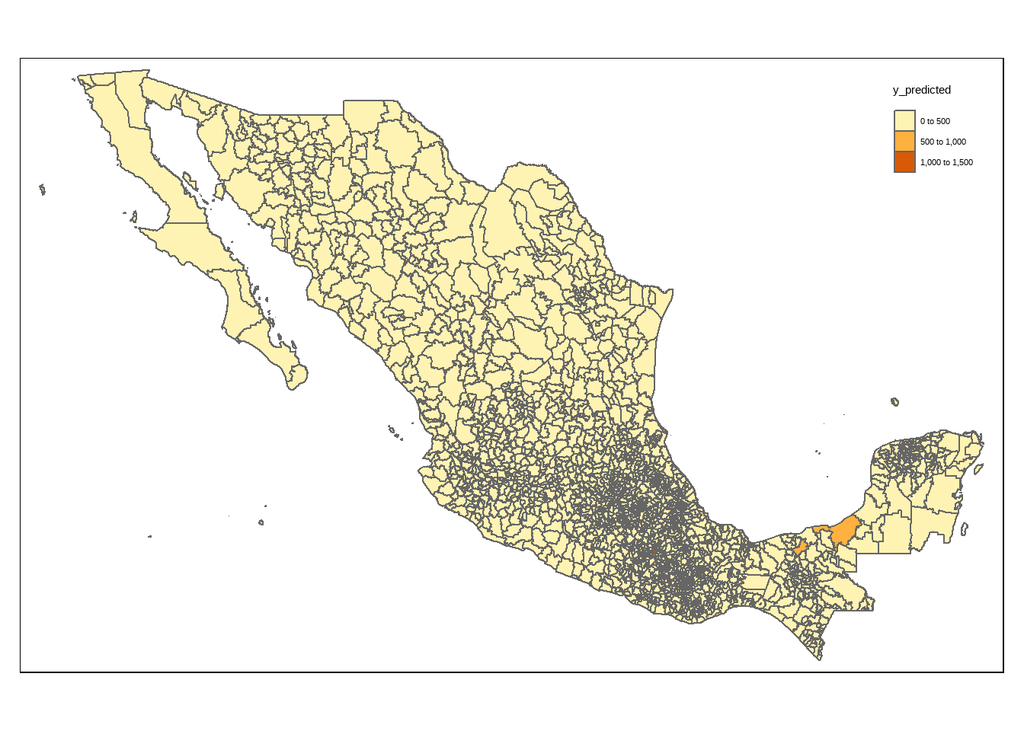

```r
gwr_sf2$y_predicted <- exp(gwr_sf2$yhat)
qtm(gwr_sf2, "y_predicted")
```

```r
#mapview(gwr_sf2, zcol = "y_predicted")
```

Predicción local de variables explicativas estadísticamente significativas

```r
qtm(gwr_sf2, "hogremjefmuj2015_TV")
```

```
## Variable(s) "hogremjefmuj2015_TV" contains positive and negative values, so midpoint is set to 0. Set midpoint = NA to show the full spectrum of the color palette.
```

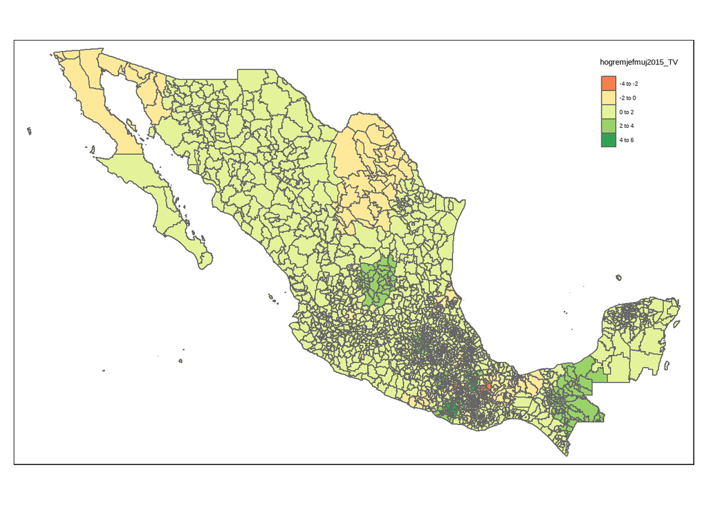

```r
qtm(gwr_sf2, "porcentaje_pob_acceso_ss_TV")
```

```
## Variable(s) "porcentaje_pob_acceso_ss_TV" contains positive and negative values, so midpoint is set to 0. Set midpoint = NA to show the full spectrum of the color palette.
```

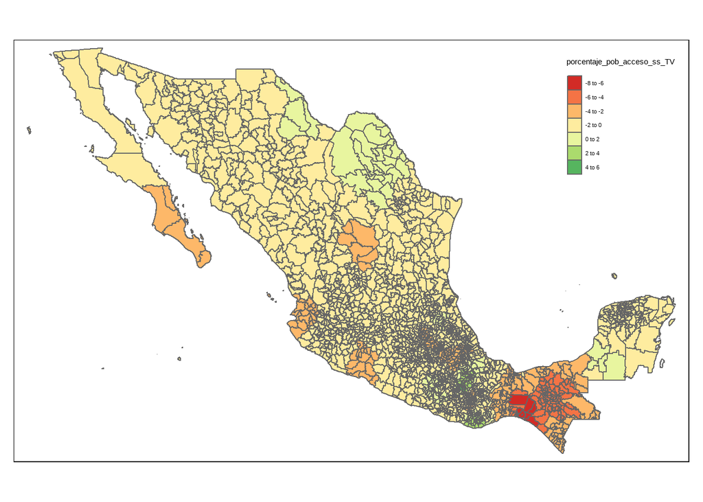

```r
#mapview(gwr_sf2, zcol = "hogremjefmuj2015_TV")
#mapview(gwr_sf2, zcol = "porcentaje_pob_acceso_ss_TV")
```

Predicción local de R2

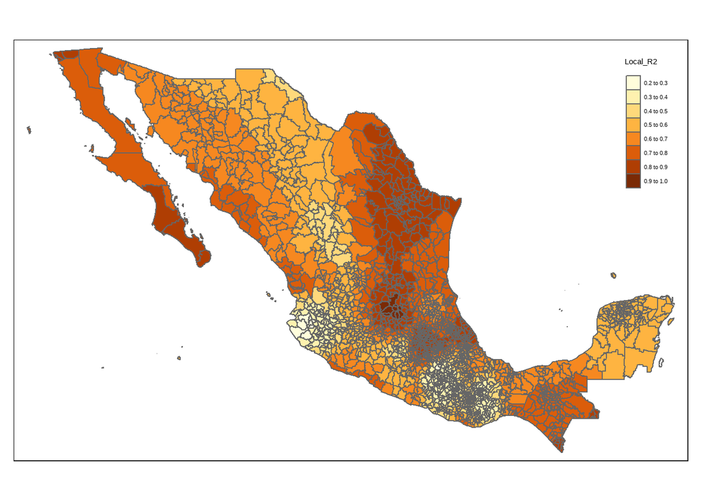

```r
qtm(gwr_sf2, "Local_R2")
```

```r
#mapview(gwr_sf2, zcol = "Local_R2")
```

La predicción local de R al cuadrado tiene como valores más altos los estados de los municipios en la región Norte y Noroeste. Las regiones del centro y sur son las que categóricamente hablando juntaron el valor mínimo.

Residuos de regresión local

```r
qtm(gwr_sf2, "residual")
```

```
## Variable(s) "residual" contains positive and negative values, so midpoint is set to 0. Set midpoint = NA to show the full spectrum of the color palette.
```

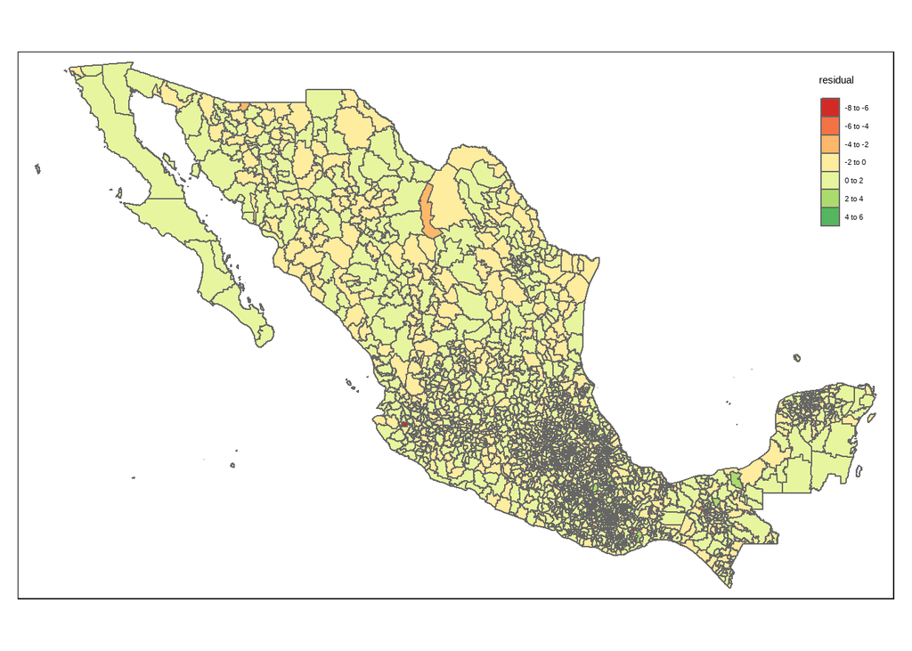

```r
#mapview(gwr_sf2, zcol = "residual")
```

Visualizar más de 2 variables explicativas

[figure not shown]

```r
map_4 <- tm_shape(gwr_sf2) +
  tm_polygons(col = "hogremjefmuj2015_TV", style = "quantile", palette = "BuGn", title = "P-Value de jefa de familia")
map_5 <- tm_shape(gwr_sf2) +
  tm_polygons(col = "porcentaje_pob_acceso_ss_TV", style = "quantile", palette = "-BuGn", title = "P-Value de porcentaje poblacion con acceso a ss")
tmap_arrange(map_4, map_5, ncol = 2)
```

Podemos notar una alta concentración de valores negativos en porcentaje de población con acceso a servicio social a lo largo del país.

Los principales hallazgos basados en resultados locales.

Tabla de coeficientes GWR

```r
gwr_table2 = apply(m.gwr2$SDF@data[,1:7], 2, summary)
```

Coeficientes OLS

```r
non_spatial_model2_table = coef(non_spatial_model2)
```

Juntarlos con un row link

```r
table33 <- rbind(gwr_table2, non_spatial_model2_table)
```

Agregar nombre a la última fila de la pestaña

```r
rownames(table33) [7] <- "Global"
```

Transpose tab Resumen de modelos estimados no espaciales y GWR

```r
table33 <- t(round(table33, 3))
table33
```

```
##                                  Min. 1st Qu. Median   Mean 3rd Qu.  Max.
## Intercept                      -3.065   3.922  4.776  4.575   5.660 9.961
## hogremjefmuj2015               -0.078   0.006  0.022  0.025   0.044 0.133
## log(crimen_2019)               -0.053   0.018  0.039  0.064   0.094 0.272
## porcentaje_pob_servicios_salud -0.069  -0.011 -0.003  0.000   0.010 0.080
## porcentaje_pob_acceso_ss       -0.107  -0.028 -0.016 -0.018  -0.007 0.064
## rezago_social                  -2.203  -0.746 -0.506 -0.510  -0.214 0.917
## y                              -4.605   3.185  4.072  3.786   4.864 7.327
##                                Global
## Intercept                       5.717
## hogremjefmuj2015                0.015
## log(crimen_2019)                0.065
## porcentaje_pob_servicios_salud  0.000
## porcentaje_pob_acceso_ss       -0.003
## rezago_social                  -0.309
## y                              -0.030
```

# Hallazgos

- Los resultados de la regresión local que muestra la estimación del modelo GWR indican un AIC más bajo que los resultados de la regresión global espacial y no espacial. Basandonos en el AIC más bajo, seleccionamos el GWR
- Jefa de familia que recibe remesas es una variable estadística mente significativa en cuanto a la detección de casos confirmados de COVID -19 en México la mayor concentración de esta variable se observa en las regiones centro norte y sur del país.
- Local R2 es significativamente alta en las regiones turísticas (playas), la capital del país, Nuevo León y la zona fronteriza de Tamaulipas.

# Recomendaciones

- Dentro de las variables explicativas, el porcentaje de la población que tiene acceso a ss es negativo en casi todo el país. Esto demuestra que hay áreas de oportunidad para incrementar estos porcentajes en estos sectores
- La dispersión entre máximo y mínimo en la variable de crimen contiene valores muy cercanos, por lo que se recomienda usar el modelo Kennel Bardwith para una transición más sencilla en la aplicación.
- Como se observó en los mapas que utilizan la variable de rezago social este tiene concentraciones altas en ciertas áreas de la región norte pero una gran distribución a lo largo de la región sur por lo tanto se recomienda implementar actividades socioeconómicas que beneficien a esta región para que el rezago social tenga una distribución normal a lo largo de México.

# Conclusión

En conclusión podemos determinar que los modelos de regresión no espacial y global espacial muestran resultados significativos en cuanto a la explicación de la variable predictiva en este caso tasa de covid sin embargo el modelo de regresión espacial local muestra mejores resultados en cuanto a la relación de las variables explicativas y la variable dependiente.